# Working with dates

## Module datetime

```python
import datetime as dt
x = dt.datetime.now()
y = dt.date.today()
print(x)
```

```
## 2019-01-31 20:46:39.654316
```

```python
print(y)
```

```
## 2019-01-31
```

## Classes in datetime module

- date class
- time class
- datetime class
- timedelta class

## Date class (1)

- dt.date(2019,1,31): date object to represent a date
- dt.date.today(): current date

```python
today = dt.date.today()
print("Current year:", today.year)
```

```
## Current year: 2019
```

```python
print("Current month:", today.month)
```

```
## Current month: 1
```

```python
print("Current day:", today.day)
```

```
## Current day: 31
```

## Date class (2)

- weekday (number)
- Monday is 0 and Sunday is 6

```python
print("Weekday no:", today.weekday())
```

```
## Weekday no: 3
```

## Lab

What is the weekday of your birthday?

## Time class (1)

```python
from datetime import time
a = time()
# time(hour = 0, minute = 0, second = 0)
print("a =", a)
```

```
## a = 00:00:00
```

```python
b = time(11, 34, 56)
# time(hour, minute and second)
print("b =", b)
```

```
## b = 11:34:56
```

```python
c = time(hour = 11, minute = 34, second = 56)
# time(hour, minute and second)
print("c =", c)
```

```
## c = 11:34:56
```

## Time class (2)

```python
a = time(11, 34, 56)
print("hour =", a.hour)
```

```
## hour = 11
```

```python
print("minute =", a.minute)
```

```
## minute = 34
```

```python
print("second =", a.second)
```

```
## second = 56
```

```python
print("microsecond =", a.microsecond)
```

```
## microsecond = 0
```

## Datetime class (1)

```python
from datetime import datetime
a = datetime(2018, 11, 28)
#datetime(year, month, day)
print(a)
```

```
## 2018-11-28 00:00:00
```

```python
b = datetime(2017, 11, 28, 23, 55, 59, 342380)
# datetime(year, month, day, hour, minute, second, microsecond)
print(b)
```

```
## 2017-11-28 23:55:59.342380
```

## Datetime class (2)

```python
a = datetime(2017, 11, 28, 23, 55, 59, 342380)
print("year =", a.year)
```

```
## year = 2017
```

```python
print("month =", a.month)
```

```
## month = 11
```

```python
print("hour =", a.hour)
```

```
## hour = 23
```

```python
print("minute =", a.minute)
```

```
## minute = 55
```

## Lab

Print the current hour and minute.

## Format dates (1)

- datetime to string using strftime(codes)

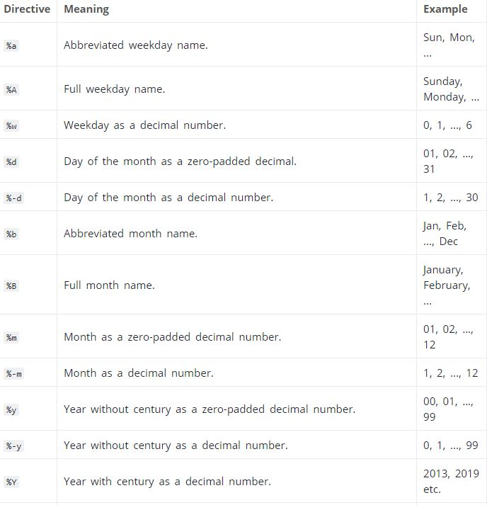

## Format dates (2)

```python
from datetime import datetime
# current date and time
now = datetime.now()
t = now.strftime("%H:%M:%S")
print("time:", t)
```

```
## time: 20:46:40
```

```python
s1 = now.strftime("%m/%d/%Y, %H:%M:%S")
# mm/dd/YY H:M:S format
print("s1:", s1)
```

```
## s1: 01/31/2019, 20:46:40
```

```python
s2 = now.strftime("%d/%m/%Y, %H:%M:%S")
# dd/mm/YY H:M:S format
print("s2:", s2)
```

```
## s2: 31/01/2019, 20:46:40
```

## Lab

Please specify your birthday in the following format:

- Thursday, 1980-06-01
- 01-Jun-1980, Thu

## Parsing strings to datetime (1)

- strptime(string, format) from datetime module

```python
dateS="31.01.2019"
toDate=dt.datetime.strptime(dateS,"%d.%m.%Y")
print(toDate)
```

```
## 2019-01-31 00:00:00
```

## Parsing strings to datetime (2)

- pandas has to_datetime() function

```
##                          date  value
## 0  2014-05-01 18:47:05.069722      1
## 1  2014-05-01 18:47:05.119994      1
## 2  2014-05-02 18:47:05.178768      1
## 3  2014-05-02 18:47:05.230071      1
## 4  2014-05-02 18:47:05.230071      1
```

```
## 0    2014-05-01 18:47:05.069722
## 1    2014-05-01 18:47:05.119994
## 2    2014-05-02 18:47:05.178768
## 3    2014-05-02 18:47:05.230071
## 4    2014-05-02 18:47:05.230071
## 5    2014-05-02 18:47:05.280592
## 6    2014-05-03 18:47:05.332662
## 7    2014-05-03 18:47:05.385109
## 8    2014-05-04 18:47:05.436523
## 9    2014-05-04 18:47:05.486877
## Name: date, dtype: object
```

## Parsing strings to datetime (3)

- pandas has to_datetime() function

```python
print(pd.to_datetime(df['date']))
```

```
## 0   2014-05-01 18:47:05.069722
## 1   2014-05-01 18:47:05.119994
## 2   2014-05-02 18:47:05.178768
## 3   2014-05-02 18:47:05.230071
## 4   2014-05-02 18:47:05.230071
## 5   2014-05-02 18:47:05.280592
## 6   2014-05-03 18:47:05.332662
## 7   2014-05-03 18:47:05.385109
## 8   2014-05-04 18:47:05.436523
## 9   2014-05-04 18:47:05.486877
## Name: date, dtype: datetime64[ns]
```

## Parsing strings to datetime (4)

- to_datetime() function accepts strptime format

```python
import locale as l
l.setlocale(l.LC_ALL, "")
#setting to US locale
l.setlocale(l.LC_ALL,"English")
data = {'date': ['Tor., 2019-Jan.-01', 'Pet., 2019-Feb.-01', 'Pet., 2019-Mar.-01'],
        'value': [1, 1, 1]}
df = pd.DataFrame(data, columns = ['date', 'value'])
print(pd.to_datetime(df['date'], format="%a, %Y-%b-%d"))
```

```
## ValueError: time data 'Tor., 2019-Jan.-01' does not match format '%a, %Y-%b-%d' (match)
##
## Detailed traceback:
##   File "<string>", line 1, in <module>
##   File "C:\Users\Godnov\ANACON~1\lib\site-packages\pandas\core\tools\datetimes.py", line 451, in to_datetime
##     values = _convert_listlike(arg._values, True, format)
##   File "C:\Users\Godnov\ANACON~1\lib\site-packages\pandas\core\tools\datetimes.py", line 380, in _convert_listlike
##     raise e
##   File "C:\Users\Godnov\ANACON~1\lib\site-packages\pandas\core\tools\datetimes.py", line 347, in _convert_listlike
##     errors=errors)
##   File "pandas\_libs\tslibs\strptime.pyx", line 157, in pandas._libs.tslibs.strptime.array_strptime
```

## Parsing strings to datetime (5)

- we get error, because we have different locale. We should set a locale to Slovenian.
- using locale module

```python
import locale as l
l.setlocale(l.LC_ALL,"Slovenian")
data = {'date': ['Tor., 2019-Jan.-01', 'Pet., 2019-Feb.-01', 'Pet., 2019-Mar.-01'],
        'value': [1, 1, 1]}
df = pd.DataFrame(data, columns = ['date', 'value'])
df["date"]=pd.to_datetime(df['date'], format="%a, %Y-%b-%d")
print(df)
```

```
##         date  value
## 0 2019-01-01      1
## 1 2019-02-01      1
## 2 2019-03-01      1
```

## Parsing strings to datetime (6)

- changing format of date changes datatype to string

```python
from datetime import datetime as dt
#changing format of date column
df["date"]=df["date"].dt.strftime("%d.%m.%Y")
print(df)
#changing format of date column to german names
```

```
##          date  value
## 0  01.01.2019      1
## 1  01.02.2019      1
## 2  01.03.2019      1
```

```python
l.setlocale(l.LC_ALL,"German")
df["date"]=pd.to_datetime(df["date"], format="%d.%m.%Y").dt.strftime("%d.%m.%Y, %A")
print(df)
```

```
##                    date  value
## 0  01.01.2019, Dienstag      1
## 1   01.02.2019, Freitag      1
## 2   01.03.2019, Freitag      1
```

```python
l.setlocale(l.LC_ALL,"Slovenian")
```

## Lab

In this exercise you will work with the date, “1930-08-30”, Warren Buffett’s birth date! Mind the locale language!  
- convert “08,30,1930” to a date (it is in the form of “month,day,year”)  
- convert “Aug 30,1930” to a date  
- convert “30aug1930” to a date

## Lab

Take Master DF. Select the following columns:  
- birthYear  
- birthMonth  
- birthDay  
- deathYear  
- deathMonth  
- deathDay  
- nameLast  
- nameGiven

Exclude row with any null value. For every player nameLast and nameGiven show the date of birth and date of death in format: weekday, dd.mm.yy in English. Show random 10 rows.  
*Hint1*: dfDates[“birthDate”]= pd.to_datetime(dict(year=dfDates.birthYear,month=dfDates.birthMonth, day=dfDates.birthDay)).  
*Hint2*: dataframe.sample(10)

## Timedelta class (1)

- timedelta object represents the difference between two dates or times
- simple subtraction

```python
from datetime import datetime, date
t1 = date(year = 2018, month = 7, day = 12)
t2 = date(year = 2017, month = 12, day = 23)
t3 = t1 - t2
print("t3 =", t3)
```

```
## t3 = 201 days, 0:00:00
```

```python
t4 = datetime(year = 2018, month = 7, day = 12, hour = 7, minute = 9, second = 33)
t5 = datetime(year = 2019, month = 6, day = 10, hour = 5, minute = 55, second = 13)
t6 = t4 - t5
print("t6 =", t6)
```

```
## t6 = -333 days, 1:14:20
```

## Timedelta class (2)

- expressing differnce in different units
- relativedelta for calculating years and months between 2 dates

```python
from datetime import datetime, date
from dateutil import relativedelta
t1 = date(year = 2018, month = 7, day = 12)
t2 = date(year = 2013, month = 12, day = 23)
t3 = relativedelta.relativedelta(t1, t2)
t3_d = t1-t2
print("t3 (years) =", t3.years)
```

```
## t3 (years) = 4
```

```python
print("t3 (months) =", t3.years*12+t3.months)
```

```
## t3 (months) = 54
```

```python
print("t3 (days) =", t3_d.days)
```

```
## t3 (days) = 1662
```

## Timedelta class (3)

- difference between two timedelta objects

```python
from datetime import timedelta
t1 = timedelta(weeks = 2, days = 5, hours = 1, seconds = 33)
t2 = timedelta(days = 4, hours = 11, minutes = 4, seconds = 54)
t3 = t1 - t2
print("t3 =", t3)
```

```
## t3 = 14 days, 13:55:39
```

## Difference between dates in pandas (1)

- using timedelta64 from numpy

```
##   Start_date   End_date
## 0 2012-01-31 2018-03-11
## 1 2012-02-29 2018-03-18
## 2 2012-03-31 2018-03-25
## 3 2012-04-30 2018-04-01
## 4 2012-05-31 2018-04-08
## 5 2012-06-30 2018-04-15
## 6 2012-07-31 2018-04-22
```

## Difference between dates in pandas (2)

- difference in days: timedelta64(1,‘D’)
- difference in months: timedelta64(1,‘M’)
- difference in years: timedelta64(1,‘Y’)

```python
df['diff_days'] = df['End_date'] - df['Start_date']
df['diff_days']=df['diff_days']/np.timedelta64(1,'D')
df.diff_days=df.diff_days.astype(int).round(0)
## Difference in days
print(df)
```

```
##   Start_date   End_date  diff_days
## 0 2012-01-31 2018-03-11       2231
## 1 2012-02-29 2018-03-18       2209
## 2 2012-03-31 2018-03-25       2185
## 3 2012-04-30 2018-04-01       2162
## 4 2012-05-31 2018-04-08       2138
## 5 2012-06-30 2018-04-15       2115
## 6 2012-07-31 2018-04-22       2091
```

## Difference between dates in pandas (3)

```python
df['diff_months'] = df['End_date'] - df['Start_date']
df['diff_months']=df['diff_months']/np.timedelta64(1,'M')
df.diff_months=df.diff_months.astype(int).round(0)
## Difference in months
print(df)
```

```
##   Start_date   End_date  diff_days  diff_months
## 0 2012-01-31 2018-03-11       2231           73
## 1 2012-02-29 2018-03-18       2209           72
## 2 2012-03-31 2018-03-25       2185           71
## 3 2012-04-30 2018-04-01       2162           71
## 4 2012-05-31 2018-04-08       2138           70
## 5 2012-06-30 2018-04-15       2115           69
## 6 2012-07-31 2018-04-22       2091           68
```

## Difference between dates in pandas (4)

```python
df['diff_years'] = df['End_date'] - df['Start_date']
df['diff_years']=df['diff_years']/np.timedelta64(1,'Y')
df.diff_years=df.diff_years.astype(int).round(0)
## Difference in years
print(df)
```

```
##   Start_date   End_date  diff_days  diff_months  diff_years
## 0 2012-01-31 2018-03-11       2231           73           6
## 1 2012-02-29 2018-03-18       2209           72           6
## 2 2012-03-31 2018-03-25       2185           71           5
## 3 2012-04-30 2018-04-01       2162           71           5
## 4 2012-05-31 2018-04-08       2138           70           5
## 5 2012-06-30 2018-04-15       2115           69           5
## 6 2012-07-31 2018-04-22       2091           68           5
```

## Lab

Take DF from previous excercise and:  
- calculate the age of players in days, months and years  
- find the youngest and oldest player by age in days